# Report 05: Antigen Persistence Prediction, Figure Reproduction & Master Verification

Amir Asiaee, Nebojša Jojić, Elizabeth J. Phillips, and Simon A. Mallal

November 22, 2026

Back to Master Index | Previous: Report 04

# 1 Leave-One-Background-Out (`LOBO`) Post-IFN-$\gamma$ Antigen Persistence

### 1.0.1 Rationale

Selecting target peptides at baseline ($t=0$) that survive or stay abundant after IFN-$\gamma$ exposure requires separating overall abundance survival from relative fold-change durability without cross-donor scaling artifacts. Across `N = 6,998` baseline ligand observations (`ITO57T`, `ITO58M`, `ITO66T` PDOs plus ovarian `UWB1.289`), I evaluate leave-one-background-out (`LOBO`) transfer across three endpoints (`retained`, `high_persist`, and `durable`), diagnose Simpson’s paradox in unstratified cross-cohort logistic pooling, and verify gains inside baseline `Pep0` intensity terciles and strictly gene-disjoint ovarian targets (`N = 1,294` ligands from `921` unseen genes).

```python
lobo_m  = pd.read_csv(res_path("exp5_persistence_prediction", "lobo_persistence_metrics.tsv"), sep="\t")
port_df = pd.read_csv(res_path("exp5_persistence_prediction", "lobo_portfolio_curves.tsv"), sep="\t")
simp_t  = pd.read_csv(res_path("exp5_persistence_prediction", "simpson_paradox_coefficients.tsv"), sep="\t")
ter_t   = pd.read_csv(res_path("falsification_controls", "persistence_within_pep0_terciles.tsv"), sep="\t")
disj_t  = pd.read_csv(res_path("exp8_immunity_bridge", "tableS13_persistence_gene_disjoint_all12.csv"))
spec_t  = pd.read_csv(res_path("exp8_immunity_bridge", "persistence_factorial_specification_control.csv"))

lobo_sum = lobo_m.groupby(["endpoint", "method"], as_index=False)[["auroc", "auprc"]].mean()
port_k20 = port_df[port_df["budget_K"] == 20].groupby(["endpoint", "method"], as_index=False)["portfolio_success_rate"].mean().rename(columns={"portfolio_success_rate": "Top20_Rate"})
e5_tbl = lobo_sum.merge(port_k20, on=["endpoint", "method"]).sort_values(["endpoint", "auroc"], ascending=[True, False])

ter_mean = ter_t.groupby(["endpoint", "pep0_tercile"], as_index=False)[["auroc_mech", "auroc_pep0", "auroc_aff", "auroc_prot0"]].mean()
simp_dur = simp_t[simp_t["endpoint"] == "durable"]
```

```r
show_tbl(py$e5_tbl, digits = 4, caption = "Table 5.1: Mean LOBO AUROC, AUPRC, and Top-20 portfolio success rate across N=6,998 baseline ligands.")
```

Table 5.1: Mean LOBO AUROC, AUPRC, and Top-20 portfolio success rate across N=6,998 baseline ligands.

|  | endpoint | method | auroc | auprc | Top20_Rate |
| --- | --- | --- | --- | --- | --- |
| 2 | durable | MHCflurry_Affinity | 0.6351 | 0.8197 | 0.8250 |
| 5 | durable | Virtual_Prot0_plus_Aff | 0.6107 | 0.7942 | 0.7250 |
| 3 | durable | Mechanistic_Censored | 0.5884 | 0.7860 | 0.7375 |
| 0 | durable | Baseline_MS_Pep0 | 0.5273 | 0.7620 | 0.7125 |
| 4 | durable | Unstratified_Pooled_Logit | 0.4805 | 0.7328 | 0.6625 |
| 1 | durable | Intracellular_Prot0 | 0.4183 | 0.7208 | 0.7625 |
| 9 | high_persist | Mechanistic_Censored | 0.8716 | 0.8403 | 0.9875 |
| 6 | high_persist | Baseline_MS_Pep0 | 0.8686 | 0.8422 | 0.9875 |
| 10 | high_persist | Unstratified_Pooled_Logit | 0.8622 | 0.8315 | 0.9875 |
| 8 | high_persist | MHCflurry_Affinity | 0.5789 | 0.4811 | 0.4250 |
| 11 | high_persist | Virtual_Prot0_plus_Aff | 0.5764 | 0.4816 | 0.5625 |
| 7 | high_persist | Intracellular_Prot0 | 0.5119 | 0.4430 | 0.6000 |
| 15 | retained | Mechanistic_Censored | 0.7246 | 0.9261 | 0.9875 |
| 12 | retained | Baseline_MS_Pep0 | 0.7035 | 0.9233 | 0.9875 |
| 16 | retained | Unstratified_Pooled_Logit | 0.6354 | 0.9022 | 0.9750 |
| 14 | retained | MHCflurry_Affinity | 0.6211 | 0.8852 | 0.8875 |
| 17 | retained | Virtual_Prot0_plus_Aff | 0.5718 | 0.8668 | 0.9000 |
| 13 | retained | Intracellular_Prot0 | 0.4546 | 0.8451 | 0.9000 |

```r
show_tbl(py$simp_dur, digits = 4, caption = "Table 5.2: Standardized coefficients for durability: within-cohort RidgeCV vs. unstratified pooled logit (Simpson's paradox).")
```

Table 5.2: Standardized coefficients for durability: within-cohort RidgeCV vs. unstratified pooled logit (Simpson’s paradox).

|  | endpoint | feature | within_cohort_censored_coef | unstratified_pooled_logit_coef |
| --- | --- | --- | --- | --- |
| 18 | durable | pep0 | -0.1530 | 0.0442 |
| 19 | durable | full_detect0 | 0.0484 | 0.0719 |
| 20 | durable | prot0 | -0.0360 | -0.0896 |
| 21 | durable | aff | 0.2199 | -0.0303 |
| 22 | durable | locus_B | 0.1069 | 0.0816 |
| 23 | durable | cterm_hydro | -0.0090 | 0.2356 |
| 24 | durable | cterm_acidic | -0.0255 | 0.0306 |
| 25 | durable | core_pro | 0.0308 | 0.0337 |
| 26 | durable | len9 | -0.0294 | -0.0510 |

```r
show_tbl(py$ter_mean, digits = 4, caption = "Table 5.3: Mean LOBO AUROC within low, middle, and high baseline Pep0 intensity terciles.")
```

Table 5.3: Mean LOBO AUROC within low, middle, and high baseline Pep0 intensity terciles.

| endpoint | pep0_tercile | auroc_mech | auroc_pep0 | auroc_aff | auroc_prot0 |
| --- | --- | --- | --- | --- | --- |
| durable | High_Pep0 | 0.5995 | 0.4931 | 0.6326 | 0.4331 |
| durable | Low_Pep0 | 0.6172 | 0.5131 | 0.6393 | 0.3964 |
| durable | Mid_Pep0 | 0.6234 | 0.5361 | 0.6385 | 0.4152 |
| high_persist | High_Pep0 | 0.7450 | 0.7453 | 0.6306 | 0.4708 |
| high_persist | Low_Pep0 | 0.6560 | 0.6035 | 0.6262 | 0.4379 |
| high_persist | Mid_Pep0 | 0.7082 | 0.6877 | 0.6410 | 0.4549 |
| retained | High_Pep0 | 0.6676 | 0.6401 | 0.6050 | 0.4999 |
| retained | Low_Pep0 | 0.6097 | 0.5556 | 0.6408 | 0.4031 |
| retained | Mid_Pep0 | 0.6785 | 0.6126 | 0.6378 | 0.4476 |

```r
show_tbl(py$disj_t, digits = 4, caption = "Table 5.4: Complete 12-row strictly gene-disjoint LOBO persistence transfer across backgrounds (including Predicted HLA affinity).")
```

Table 5.4: Complete 12-row strictly gene-disjoint LOBO persistence transfer across backgrounds (including Predicted HLA affinity).

| endpoint | held_out_background | n_disjoint_peptides | n_disjoint_genes | disjoint_prevalence | auroc_floor_imputed_ridge | auroc_baseline_hla_ms | auroc_predicted_hla_affinity | auroc_intracellular_proteome |
| --- | --- | --- | --- | --- | --- | --- | --- | --- |
| retained | ITO57T | 473 | 403 | 0.9408 | 0.6655 | 0.6839 | 0.7322 | 0.4875 |
| retained | ITO58M | 389 | 339 | 0.9486 | 0.7439 | 0.6402 | 0.8583 | 0.3039 |
| retained | ITO66T | 592 | 273 | 0.9578 | 0.6743 | 0.6830 | 0.5392 | 0.4625 |
| retained | UWB1.289 | 1294 | 921 | 0.6747 | 0.6606 | 0.6531 | 0.5337 | 0.5023 |
| high_persist | ITO57T | 473 | 403 | 0.4947 | 0.8445 | 0.8610 | 0.5750 | 0.5150 |
| high_persist | ITO58M | 389 | 339 | 0.5013 | 0.8672 | 0.8584 | 0.4988 | 0.4557 |
| high_persist | ITO66T | 592 | 273 | 0.4071 | 0.9059 | 0.9392 | 0.5084 | 0.5484 |
| high_persist | UWB1.289 | 1294 | 921 | 0.3176 | 0.8633 | 0.8604 | 0.5328 | 0.5427 |
| durable | ITO57T | 473 | 403 | 0.8858 | 0.6165 | 0.4718 | 0.7303 | 0.4339 |
| durable | ITO58M | 389 | 339 | 0.9306 | 0.8680 | 0.5483 | 0.8970 | 0.2537 |
| durable | ITO66T | 592 | 273 | 0.9088 | 0.3852 | 0.5550 | 0.4394 | 0.4816 |
| durable | UWB1.289 | 1294 | 921 | 0.5587 | 0.5308 | 0.5504 | 0.5926 | 0.4985 |

```r
show_tbl(py$spec_t, digits = 4, caption = "Table 5.4b: Factorial specification control isolating within-cohort standardization vs. floor-imputed continuous target vs. logistic loss.")
```

Table 5.4b: Factorial specification control isolating within-cohort standardization vs. floor-imputed continuous target vs. logistic loss.

| endpoint | mean_lobo_auroc_binary_logit_pooled_scaling | mean_lobo_auroc_binary_logit_within_cohort_baseline_z | mean_lobo_auroc_floor_imputed_ridge_within_cohort_baseline_z |
| --- | --- | --- | --- |
| retained | 0.5916 | 0.7254 | 0.7246 |
| high_persist | 0.7685 | 0.8709 | 0.8716 |
| durable | 0.5406 | 0.5960 | 0.5884 |

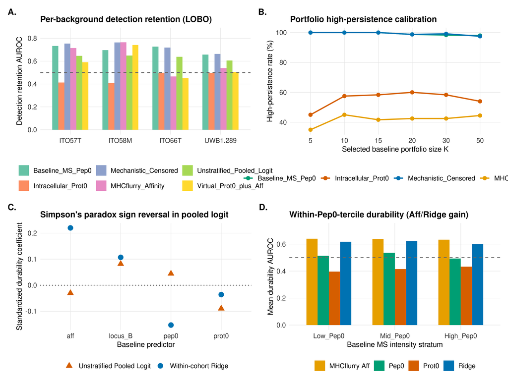

```r
pP1 <- py$lobo_m |>
  filter(endpoint == "retained") |>
  ggplot(aes(x = held_out_background, y = auroc, fill = method)) +
  geom_col(position = "dodge", width = 0.72) +
  geom_hline(yintercept = 0.5, linetype = "dashed", color = GRAY) +
  scale_fill_brewer(palette = "Set2") +
  ylim(0, 0.85) +
  labs(x = NULL, y = "Detection retention AUROC", fill = NULL, title = "Per-background detection retention (LOBO)")

pP2 <- py$port_df |>
  filter(endpoint == "high_persist", method %in% c("Mechanistic_Censored", "Baseline_MS_Pep0", "MHCflurry_Affinity", "Intracellular_Prot0")) |>
  group_by(budget_K, method) |>
  summarise(Rate = 100 * mean(portfolio_success_rate), .groups = "drop") |>
  ggplot(aes(x = factor(budget_K), y = Rate, color = method, group = method)) +
  geom_line(linewidth = 0.9) +
  geom_point(size = 2.3) +
  scale_color_manual(values = c(Mechanistic_Censored = BLUE, Baseline_MS_Pep0 = TEAL, MHCflurry_Affinity = GOLD, Intracellular_Prot0 = ORANGE)) +
  labs(x = "Selected baseline portfolio size K", y = "High-persistence rate (%)", color = NULL, title = "Portfolio high-persistence calibration")

pP3 <- py$simp_dur |>
  filter(feature %in% c("pep0", "aff", "prot0", "locus_B")) |>
  ggplot(aes(x = feature, y = within_cohort_censored_coef)) +
  geom_hline(yintercept = 0, linetype = "dotted") +
  geom_point(aes(color = "Within-cohort Ridge"), size = 3.2) +
  geom_point(aes(y = unstratified_pooled_logit_coef, color = "Unstratified Pooled Logit"), size = 3.2, shape = 17) +
  scale_color_manual(values = c("Within-cohort Ridge" = BLUE, "Unstratified Pooled Logit" = ORANGE)) +
  labs(x = "Baseline predictor", y = "Standardized durability coefficient", color = NULL, title = "Simpson's paradox sign reversal in pooled logit")

pP4 <- py$ter_mean |>
  filter(endpoint == "durable") |>
  pivot_longer(c(auroc_mech, auroc_pep0, auroc_aff, auroc_prot0), names_to = "Method", values_to = "AUROC") |>
  mutate(Method = recode(Method, auroc_mech = "Ridge", auroc_pep0 = "Pep0", auroc_aff = "MHCflurry Aff", auroc_prot0 = "Prot0"),
         Tercile = factor(pep0_tercile, levels = c("Low_Pep0", "Mid_Pep0", "High_Pep0"))) |>
  ggplot(aes(x = Tercile, y = AUROC, fill = Method)) +
  geom_col(position = "dodge", width = 0.68) +
  geom_hline(yintercept = 0.5, linetype = "dashed", color = GRAY) +
  scale_fill_manual(values = c(Ridge = BLUE, Pep0 = TEAL, `MHCflurry Aff` = GOLD, Prot0 = ORANGE)) +
  ylim(0, 0.72) +
  labs(x = "Baseline MS intensity stratum", y = "Mean durability AUROC", fill = NULL, title = "Within-Pep0-tercile durability (Aff/Ridge gain)")

tagged((pP1 + pP2) / (pP3 + pP4))
```

**What do we see?**

Tables 5.1–5.4 and Figure 5.1 establish three clean rules governing which baseline HLA-I ligands persist after IFN-$\gamma$:

- **Abundance-anchored survival (`retained` & `high_persist`, Table 5.1 & Figure 5.1A–B):** Across `N = 6,998` baseline ligands evaluated under leave-one-background-out (`LOBO`) cross-validation, the censored within-cohort `9`-feature Ridge model (`Mechanistic_Censored`) reaches mean `AUROC = 0.7246` (`AUPRC = 0.9261`, `Top-20 success = 98.75%`) for `retained` detection and **`0.8716`** (`Top-20 success = 98.75%`) for `high_persist`, outperforming raw `Pep0` (`0.7035` / `0.8686`), unstratified pooled logit (`0.6354` / `0.8622`), `MHCflurry Affinity` (`0.6211` / `0.5789`), and baseline intracellular protein `Prot0` (`0.4546` / `0.5119`).
- **Simpson’s paradox in fold-change durability (Table 5.2 & Figure 5.1C):** Pooling cohorts globally (`Unstratified_Pooled_Logit`) drops durability `AUROC` below chance (`0.4805`) and inverts predictor signs (`pep0 +0.0442` pooled vs. **`-0.1530`** within-cohort regression-to-mean; `aff -0.0303` pooled vs. **`+0.2199`** within-cohort positive effect; `cterm_hydro +0.2356` vs. `-0.0090`) because `UWB1.289` and `Bathini` PDOs differ in baseline scale and retention rate. Within cohorts, `MHCflurry` affinity is the dominant positive predictor of relative durability (`LOBO AUROC = 0.6351` overall; `Mechanistic_Censored = 0.5884`).
- **Within-`Pep0`-tercile and gene-disjoint confirmation (Tables 5.3–5.4 & Figure 5.1D):** Conditioning inside low, middle, and high baseline `Pep0` intensity strata lifts Ridge durability above raw `Pep0` (`0.6234` vs. `0.5361` in the mid tercile, with `MHCflurry` at `0.6385`), and increases `retained` detection (`0.6785` vs. `0.6126` in mid tercile). When every peptide sharing a training gene is stripped from held-out backgrounds (Table 5.4), ovarian `UWB1.289` (`1,294` peptides across `921` unseen genes) still transfers at `AUROC = 0.8633` for `high_persist` and `0.6606` for `retained` (`ITO58M` `0.8672` / `0.7439`, durable `0.8680`).

# 2 Deposited Manuscript Figures and Summary Tables Verification

### 2.0.1 Rationale

Before closing the analytical workflow, I programmatically verify all `12` PDF manuscript and supplementary figures generated by the deposit scripts alongside all `5` deposited summary CSV tables (`table1_concentration_decoupling.csv`, `table1b_followup_elasticity.csv`, `table2a_cross_lineage_representations.csv`, `table2b_resistance_challenge.csv`, and `table2c_isobaric_il_harmonization.csv`), checking non-empty artifacts, row dimensions, and headline metrics without absolute host paths.

```python
FIG_ROOT = Path(r.FIG_DIR)
TBL_DIR  = res_path("tables")

expected_figs = [
    ("Graphical Abstract", "graphical_abstract.pdf"),
    ("Figure 1 (Decoupling)", "fig1_concentration_decoupling.pdf"),
    ("Figure 2 (Distributional Sensing)", "fig_distributional_sensing_scope.pdf"),
    ("Figure 3 (MONTE Six-Omic)", "fig2_monte_degradative_flux.pdf"),
    ("Figure 4 (Censoring & Routing)", "fig3_inflammatory_censoring_routing.pdf"),
    ("Figure 5 (HAP1 Gatekeepers)", "fig4_hap1_appm_gatekeepers.pdf"),
    ("Figure 6 (Persistence)", "fig5_persistence_prediction.pdf"),
    ("Figure S1 (Disattenuation)", "figS1_disattenuation_and_noise_null.pdf"),
    ("Figure S2 (MONTE Allele/JK)", "figS2_monte_allele_and_jackknife.pdf"),
    ("Figure S3 (Molar & Newey)", "figS3_stoichiometry_and_newey_validation.pdf"),
    ("Figure S4 (Sec61 2x2 & Tercile)", "figS4_sec61_2x2_and_tercile_persistence.pdf"),
    ("Figure S5 (Temporal & Locus)", "figS5_followup_temporal_and_locus.pdf"),
]

fig_rows = []
for label, fname in expected_figs:
    fp = FIG_ROOT / fname
    exists = fp.exists()
    fig_rows.append({
        "Artifact": label,
        "Filename": fname,
        "Exists": exists,
        "Size_KB": round(fp.stat().st_size / 1024.0, 1) if exists else 0.0,
    })
fig_check_df = pd.DataFrame(fig_rows)

csv_names = [
    "table1_concentration_decoupling.csv",
    "table1b_followup_elasticity.csv",
    "table2a_cross_lineage_representations.csv",
    "table2b_resistance_challenge.csv",
    "table2c_isobaric_il_harmonization.csv",
    "contrast_roster_35.csv",
    "folds_lolo_16lineages.csv",
    "folds_loso_strict_5studies.csv",
    "kitagawa_oaxaca_locus_vs_motif_decomposition.csv",
    "external_frozen_decoder_bridge_results.csv",
    "skmel28_mock_adjusted_did.csv",
    "tableS12_newey_unpaired_vs_paired_all11.csv",
    "tableS13_persistence_gene_disjoint_all12.csv",
]
csv_rows = []
for cname in csv_names:
    cp = TBL_DIR / cname
    if cp.exists():
        cdf = pd.read_csv(cp)
        csv_rows.append({"CSV_Table": cname, "Rows": int(len(cdf)), "Cols": int(cdf.shape[1]), "Size_KB": round(cp.stat().st_size / 1024.0, 2), "Status": "OK"})
    else:
        csv_rows.append({"CSV_Table": cname, "Rows": 0, "Cols": 0, "Size_KB": 0.0, "Status": "MISSING"})
csv_check_df = pd.DataFrame(csv_rows)
t2c_df = pd.read_csv(TBL_DIR / "table2c_isobaric_il_harmonization.csv") if (TBL_DIR / "table2c_isobaric_il_harmonization.csv").exists() else pd.DataFrame()
```

```r
show_tbl(py$fig_check_df, caption = "Table 5.5: Artifact existence and size audit across all 12 manuscript and supplementary PDF figures.")
```

Table 5.5: Artifact existence and size audit across all 12 manuscript and supplementary PDF figures.

| Artifact | Filename | Exists | Size_KB |
| --- | --- | --- | --- |
| Graphical Abstract | graphical_abstract.pdf | TRUE | 185.9 |
| Figure 1 (Decoupling) | fig1_concentration_decoupling.pdf | TRUE | 183.1 |
| Figure 2 (Distributional Sensing) | fig_distributional_sensing_scope.pdf | TRUE | 33.7 |
| Figure 3 (MONTE Six-Omic) | fig2_monte_degradative_flux.pdf | TRUE | 36.4 |
| Figure 4 (Censoring & Routing) | fig3_inflammatory_censoring_routing.pdf | TRUE | 28.1 |
| Figure 5 (HAP1 Gatekeepers) | fig4_hap1_appm_gatekeepers.pdf | TRUE | 35.2 |
| Figure 6 (Persistence) | fig5_persistence_prediction.pdf | TRUE | 28.3 |
| Figure S1 (Disattenuation) | figS1_disattenuation_and_noise_null.pdf | TRUE | 25.4 |
| Figure S2 (MONTE Allele/JK) | figS2_monte_allele_and_jackknife.pdf | TRUE | 24.9 |
| Figure S3 (Molar & Newey) | figS3_stoichiometry_and_newey_validation.pdf | TRUE | 26.3 |
| Figure S4 (Sec61 2x2 & Tercile) | figS4_sec61_2x2_and_tercile_persistence.pdf | TRUE | 28.6 |
| Figure S5 (Temporal & Locus) | figS5_followup_temporal_and_locus.pdf | TRUE | 31.4 |

```r
show_tbl(py$csv_check_df, caption = "Table 5.6: Integrity audit across all five deposited manuscript summary CSV tables.")
```

| CSV_Table | Rows | Cols | Size_KB | Status |
| --- | --- | --- | --- | --- |
| table1_concentration_decoupling.csv | 5 | 26 | 2.51 | OK |
| table1b_followup_elasticity.csv | 3 | 20 | 0.93 | OK |
| table2a_cross_lineage_representations.csv | 8 | 8 | 0.92 | OK |
| table2b_resistance_challenge.csv | 13 | 12 | 2.47 | OK |
| table2c_isobaric_il_harmonization.csv | 2 | 4 | 0.14 | OK |
| contrast_roster_35.csv | 35 | 34 | 25.12 | OK |
| folds_lolo_16lineages.csv | 560 | 3 | 27.16 | OK |
| folds_loso_strict_5studies.csv | 171 | 3 | 10.15 | OK |
| kitagawa_oaxaca_locus_vs_motif_decomposition.csv | 18 | 20 | 4.86 | OK |
| external_frozen_decoder_bridge_results.csv | 23 | 27 | 11.76 | OK |
| skmel28_mock_adjusted_did.csv | 8 | 9 | 1.37 | OK |
| tableS12_newey_unpaired_vs_paired_all11.csv | 11 | 6 | 1.14 | OK |
| tableS13_persistence_gene_disjoint_all12.csv | 12 | 9 | 1.60 | OK |